# NYPD SHOOTING(HISTORIC): Age, Race and Economic influence

Ayomide Aregbede

2023-02-18

# NYPD SHOOTING DATA HISTORIC.

## Data Source and Summary

Sourcing data from City Of New York at: https://data.cityofnewyork.us/api/views/833y-fsy8/rows.csv? accessType=DOWNLOAD The source data contains the incidents of shootings that occurred in New York City in the years from 2006 to 2021. The data includes demographics of the perpetrators and victims as well as location data for the incident.

This report aims to show the correlation between shootings, race, age group and prevailing economics.

It attempts to answer the following questions:

- What location and gender has the most risk of being a gunshot victim?
- What economic situation, e.g., housing setup, has the most risk of gun violence?
- What age of people needs the most counsel and help from society to prevent gun violence?
- Is New York becoming safer?
- At what seasons of the year should people and law enforcement be more conscious of the safety of citizens?

## Data setup

```r
library("tidyverse")
csv_data_url <- "https://data.cityofnewyork.us/api/views/833y-fsy8/rows.csv?accessType=DOWNLOAD"

main_data <- read_csv(csv_data_url)

summary(main_data)
```

```
##   INCIDENT_KEY        OCCUR_DATE         OCCUR_TIME           BORO
##  Min.   :  9953245   Length:25596       Length:25596      Length:25596
##  1st Qu.: 61593633   Class :character   Class1:hms        Class :character
##  Median : 86437258   Mode  :character   Class2:difftime   Mode  :character
##  Mean   :112382648                      Mode  :numeric
##  3rd Qu.:166660833
##  Max.   :238490103
##
##     PRECINCT      JURISDICTION_CODE LOCATION_DESC      STATISTICAL_MURDER_FLAG
##  Min.   :  1.00   Min.   :0.0000    Length:25596       Mode :logical
##  1st Qu.: 44.00   1st Qu.:0.0000    Class :character   FALSE:20668
##  Median : 69.00   Median :0.0000    Mode  :character   TRUE :4928
##  Mean   : 65.87   Mean   :0.3316
##  3rd Qu.: 81.00   3rd Qu.:0.0000
##  Max.   :123.00   Max.   :2.0000
##                   NA's   :2
##  PERP_AGE_GROUP       PERP_SEX          PERP_RACE         VIC_AGE_GROUP
##  Length:25596       Length:25596       Length:25596       Length:25596
##  Class :character   Class :character   Class :character   Class :character
##  Mode  :character   Mode  :character   Mode  :character   Mode  :character
##
##
##
##
##    VIC_SEX            VIC_RACE           X_COORD_CD        Y_COORD_CD
##  Length:25596       Length:25596       Min.   : 914928   Min.   :125757
##  Class :character   Class :character   1st Qu.:1000011   1st Qu.:182782
##  Mode  :character   Mode  :character   Median :1007715   Median :194038
##                                        Mean   :1009455   Mean   :207894
##                                        3rd Qu.:1016838   3rd Qu.:239429
##                                        Max.   :1066815   Max.   :271128
##
##     Latitude       Longitude        Lon_Lat
##  Min.   :40.51   Min.   :-74.25   Length:25596
##  1st Qu.:40.67   1st Qu.:-73.94   Class :character
##  Median :40.70   Median :-73.92   Mode  :character
##  Mean   :40.74   Mean   :-73.91
##  3rd Qu.:40.82   3rd Qu.:-73.88
##  Max.   :40.91   Max.   :-73.70
##
```

## General Sea level view

This section presents a high level view of quick facts gathered from our data. ### Age group correlation with perps

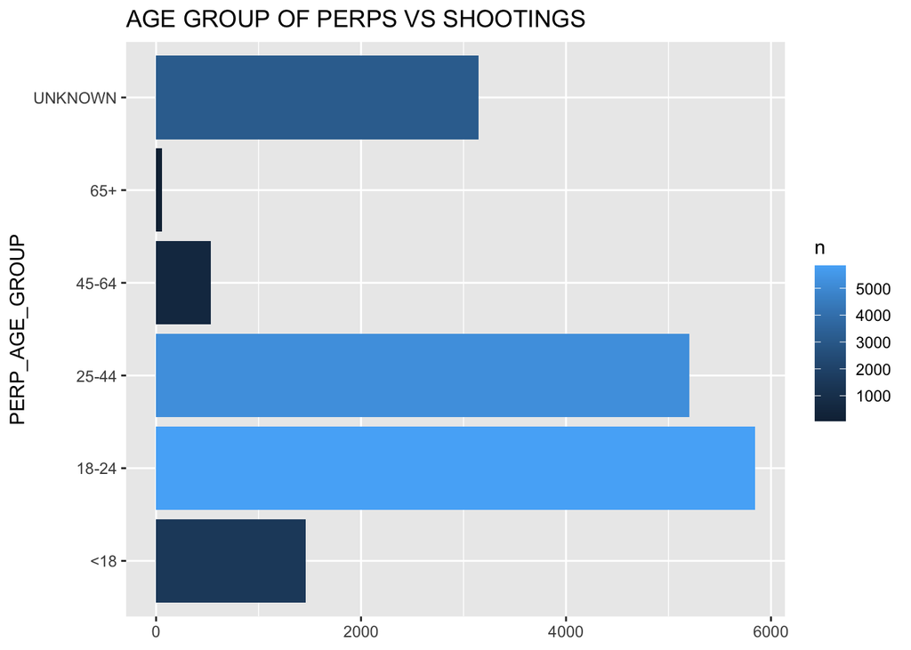

```r
perps_age_grp <- main_data %>% drop_na(PERP_AGE_GROUP) %>% count(PERP_AGE_GROUP, sort = TRUE)

perps_age_grp %>% filter(!PERP_AGE_GROUP %in% c('1020', '224', '940')) %>% ggplot(aes(x = PERP_AGE_GROUP, y = n, fill = n)) + geom_bar(stat='identity') + labs(title = "AGE GROUP OF PERPS VS SHOOTINGS", y= NULL) + coord_flip()
```

### Race correlation with perps

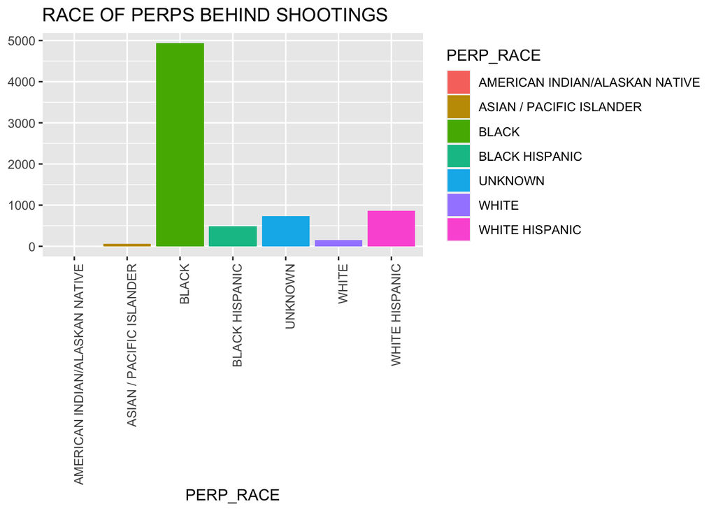

```r
perps_race <- main_data %>% drop_na() %>% count(PERP_RACE, sort = TRUE)

perps_race %>% ggplot(aes(x = PERP_RACE, y = n, fill = PERP_RACE)) + geom_bar(stat='identity') + theme(axis.text.x=element_text(angle=90, hjust=1)) + labs(title = "RACE OF PERPS BEHIND SHOOTINGS", y= NULL)
```

### Age group correlation with victims

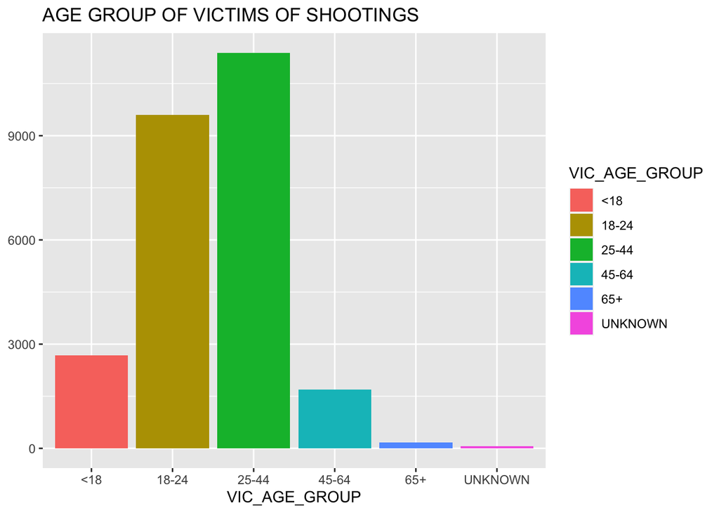

```r
vic_age_grp <- main_data %>% drop_na(VIC_AGE_GROUP) %>% count(VIC_AGE_GROUP, sort = TRUE)

vic_age_grp %>% filter(!VIC_AGE_GROUP %in% c('1020', '224', '940')) %>% ggplot(aes(x = VIC_AGE_GROUP, y = n, fill = VIC_AGE_GROUP)) + geom_bar(stat='identity') + labs(title = "AGE GROUP OF VICTIMS OF SHOOTINGS", y= NULL)
```

### Race correlation with victims

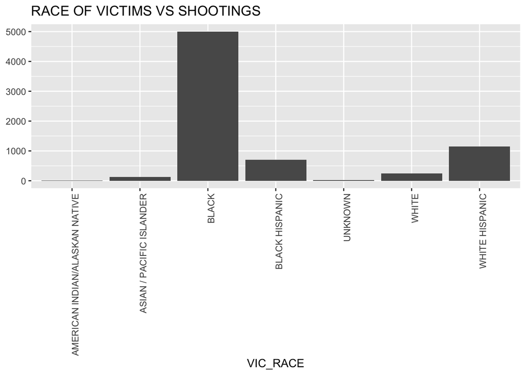

```r
vics_race <- main_data %>% drop_na() %>% count(VIC_RACE, sort = TRUE)

vics_race %>% ggplot(aes(x = VIC_RACE, y = n)) + geom_bar(stat='identity') + theme(axis.text.x=element_text(angle=90, hjust=1)) + labs(title = "RACE OF VICTIMS VS SHOOTINGS", y= NULL)
```

## Other Analysis

### Basic data prep

- Removing several fields irrelevant to the goal of this report.
- Formatting the `OCCUR_DATE` field into a date range
- Adding a new field `OCCUR_SEASON` to represent the weather seasons, e.g Summer, Winter, the shootings occurred.
- Adding a new field `OCCUR_YEAR` to represent the year the shootings occurred.

```r
library("hydroTSM")
library(lubridate)
analytics_data <- main_data %>% mutate(OCCUR_DATE = mdy(OCCUR_DATE)) %>% select(-c(X_COORD_CD, Y_COORD_CD, Latitude, Longitude, Lon_Lat, JURISDICTION_CODE, STATISTICAL_MURDER_FLAG)) %>%
mutate(OCCUR_SEASON = time2season(OCCUR_DATE,out.fmt = "seasons")) %>% mutate(OCCUR_YEAR = year(OCCUR_DATE))
```

### What’s the shooting trend over the seasons of the year

As we can see with the line graph below, it would seem that shootings are more in the summer. Corroborating the report with transportation data, recreational data, and general economic activities will help us better understand what the potential cause of increases shootings during Summer is. I’m biased to say more time off work, and increase propensity/desire for entertainment and the awareness of insufficiency might be the cause.

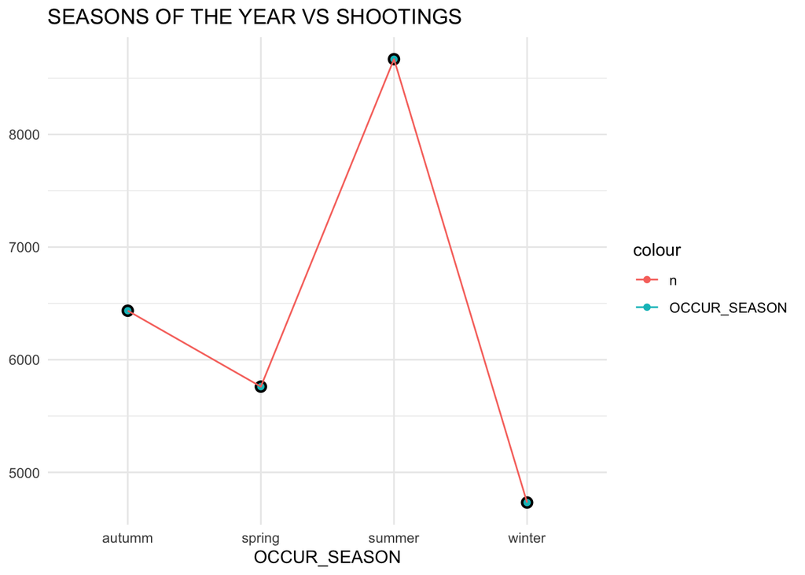

```r
analytics_data %>% count(OCCUR_SEASON, sort = TRUE) %>% ggplot(aes(x = OCCUR_SEASON, y = n, group = 1)) + geom_point(size=3) + geom_point(aes(color = "OCCUR_SEASON")) + geom_line (aes(y = n, color = "n")) + theme_minimal() + labs(title = "SEASONS OF THE YEAR VS SHOOTINGS", y= NULL)
```

### What’s the economic situation of the locations where the shootings happen?

My bias might be influencing my deduction, but the data shows a strong correlation between low income housing(related economic situations), and shootings.

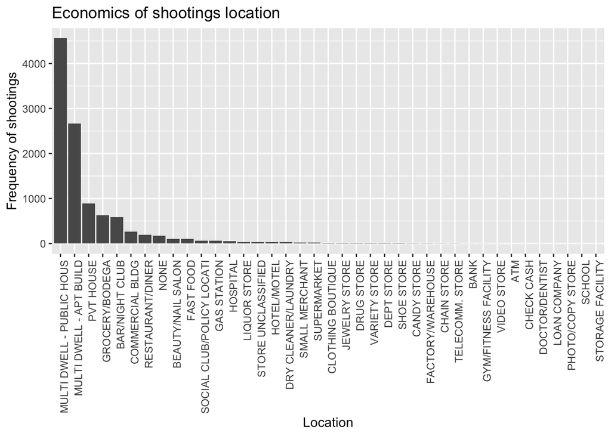

```r
analytics_data %>% count(LOCATION_DESC, sort = TRUE) %>% drop_na() %>% mutate(LOCATION_DESC = factor(LOCATION_DESC , LOCATION_DESC )) %>% ggplot(aes(x = LOCATION_DESC, y = n, group = 1)) + geom_bar(stat='identity') + theme(axis.text.x=element_text(angle=90, hjust=1)) + labs(title = "Economics of shootings location", y= "Frequency of shootings", x= "Location")
```

### What’s the location gender correlation?

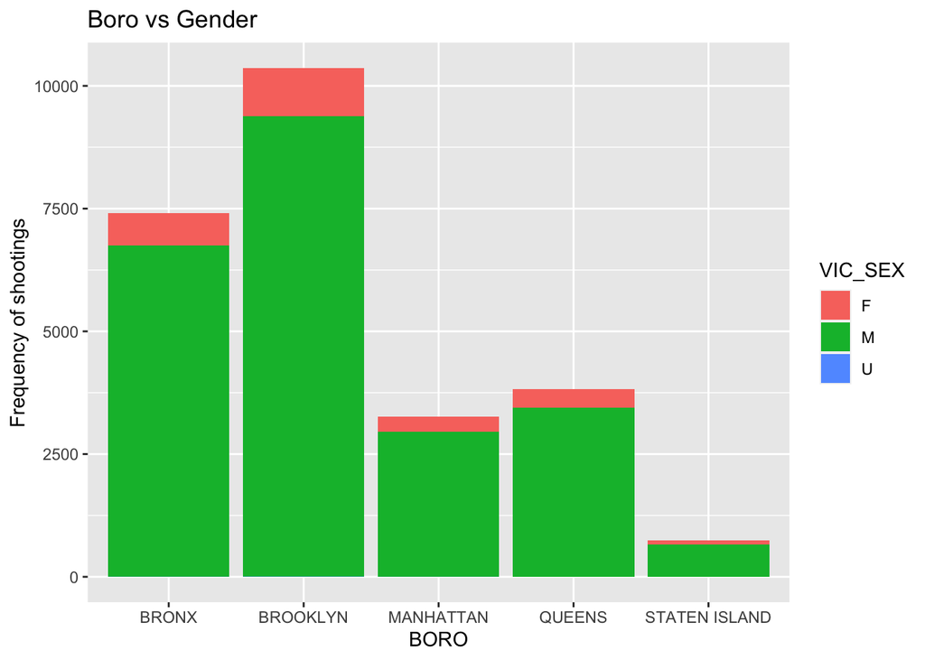

```r
analytics_data %>% count(BORO, VIC_SEX, sort = TRUE) %>% drop_na() %>% ggplot(aes(x = BORO, y = n, fill = VIC_SEX)) + geom_bar(stat='identity') + theme_grey() + labs(title = "Boro vs Gender", y= "Frequency of shootings", x= "BORO")
```

### Shooting trends

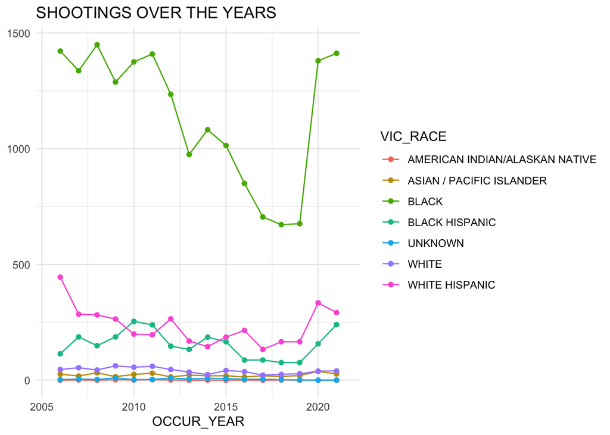

```r
library(lubridate)

analytics_data %>% ggplot(aes(group = VIC_RACE, x = OCCUR_YEAR)) + geom_line(aes(fill=..count.., color = VIC_RACE), stat="bin", binwidth=1) +
        geom_point(aes(color=VIC_RACE), stat="bin", binwidth=1) + theme_minimal() + labs(title = "SHOOTINGS OVER THE YEARS", y= NULL)
```

## Summary

Most shootings happened near Multiple dwelling zones, specifically public housing, and similar economic environments associated with low-income households. We also see that most shootings happened in Brooklyn, and most victims were primarily black victims and between the 25-44 age range.

Further analysis might clearly show the correlation between economics and gun shooting.

## Potential Bias

### Personal Bias

It is easy to assume that the race of perpetrators of most shootings would be white, however this data revealed the opposite. It is also easy to assume that most victims would be female, and the data showed the opposite.

### Bias in the Data

Similar to the initial bias that approached this report, the bias of the person reporting this data could influence the quality of the data. More so, a significant number of “unknown” and empty values could shift this report’s deductions. Finally, gun violence reporting is highly debated and can be a political tool to communicate and further discrimination.